# MetaG

Jeffrey Blanchard

2024-01-05

```r
library(tidyverse)
library(fs)
library(stringi)
library(broom)
library(DT)
library(readxl)
```

# Downloading soil MAGs from IMG

Go to IMG https://img.jgi.doe.gov/mer/ In the menu under `Find Genomes` select `metagenome bins` then `bins by ecosystem`. On the graph select `Terrestrail` then `Soil`. Select an Ecosystem subtype then in then display the list of MAGs for the subtype by clicking on the arrows. Once the table is displayed click `Select All` and then `Export`. Note that if eukcc bins exist there are tabs present for both the bacterial and eukaryotic MAGs

## Bacterial and Archaeal MAGs

```r
# define directory with files
data_dir <- "metabat"

# get list of files for checkM
IMG_metabat_files <- fs::dir_ls(data_dir, regexp = "IMG")

# import files into a tibble
IMG_metabat_all <- IMG_metabat_files %>%
  map_dfr(read_excel, .id = "file") %>%
  select(-`...1`)
```

### Reformat data frame for taxonomy and ecosystem analyses

```r
IMG_metabat_analysis <- IMG_metabat_all %>%
  separate(`Genome Name`, c("Project1","Sample Name1"), " - ", remove = FALSE,) %>%
  select(-"Sample Name1") %>%
  separate(`Project1`, c("Project","Sample Name"), "\\(Sample") %>%
  select(-"Sample Name") %>%
  separate(Ecosystem, c("Ecosystem", "Ecosystem Category", "Ecosystem Type", "Ecosystem Subtype", "Specific Ecosystem")) %>%
  separate(`GTDB-Tk Taxonomy Lineage`, c("Domain", "Phylum", "Class", "Order", "Family", "Genus", "Species"), "; ", remove = FALSE,)
write_tsv(IMG_metabat_analysis, "IMG_Terrestrail_Soil_metabat.tsv")
```

### Create a list of projects

```r
IMG_metabat_analysis_project <- IMG_metabat_analysis %>%
  group_by(`Project`) %>%
  summarise(MAGs = n())
```

```r
write_tsv(IMG_metabat_analysis_project, "IMG_Terrestrail_Soil_metabat_projects.tsv")
```

### Wrangle GTDB taxonomy to include unknowns in taxonomic analysis ()

```r
IMG_metabat_analysis_GTDB <- IMG_metabat_analysis %>%
  select(`GTDB-Tk Taxonomy Lineage`) %>%
  separate(`GTDB-Tk Taxonomy Lineage`, c("Domain", "Phylum", "Class", "Order", "Family", "Genus", "Species"), "; ") %>%
  unite(col = "classification", c(Domain, Phylum, Class, Order, Family, Genus, Species), sep='; ') %>%
  mutate_at("classification", str_replace, "Archaea", "d__Archaea") %>%
  mutate_at("classification", str_replace, "Bacteria", "d__Bacteria") %>%
  mutate_at("classification", str_replace, "; ", "|p__") %>%
  mutate_at("classification", str_replace, "; ", "|c__") %>%
  mutate_at("classification", str_replace, "; ", "|o__") %>%
  mutate_at("classification", str_replace, "; ", "|f__") %>%
  mutate_at("classification", str_replace, "; ", "|g__") %>%
  mutate_at("classification", str_replace, "; ", "|s__") %>%
  mutate_at("classification", str_replace_all, "NA", "")
# Create separate data frame for each taxonomic level
IMG_metabat_analysis_GTDB_s <- IMG_metabat_analysis_GTDB
IMG_metabat_analysis_GTDB_g <- IMG_metabat_analysis_GTDB
IMG_metabat_analysis_GTDB_f <- IMG_metabat_analysis_GTDB
IMG_metabat_analysis_GTDB_o <- IMG_metabat_analysis_GTDB
IMG_metabat_analysis_GTDB_c <- IMG_metabat_analysis_GTDB
IMG_metabat_analysis_GTDB_p <- IMG_metabat_analysis_GTDB
IMG_metabat_analysis_GTDB_d <- IMG_metabat_analysis_GTDB

# Remove lower taxonomic levels
IMG_metabat_analysis_GTDB_g$classification <- sub("\\|s__.*", "", IMG_metabat_analysis_GTDB_g$classification)
IMG_metabat_analysis_GTDB_f$classification <- sub("\\|g__.*", "", IMG_metabat_analysis_GTDB_f$classification)
IMG_metabat_analysis_GTDB_o$classification <- sub("\\|f__.*", "", IMG_metabat_analysis_GTDB_o$classification)
IMG_metabat_analysis_GTDB_c$classification <- sub("\\|o__.*", "", IMG_metabat_analysis_GTDB_c$classification)
IMG_metabat_analysis_GTDB_p$classification <- sub("\\|c__.*", "", IMG_metabat_analysis_GTDB_p$classification)
IMG_metabat_analysis_GTDB_d$classification <- sub("\\|p__.*", "", IMG_metabat_analysis_GTDB_d$classification)

# bind data frames by columns and with original dataframe
IMG_metabat_analysis_GTDB_unknowns <- bind_cols(IMG_metabat_analysis, IMG_metabat_analysis_GTDB_d, IMG_metabat_analysis_GTDB_p, IMG_metabat_analysis_GTDB_c, IMG_metabat_analysis_GTDB_o, IMG_metabat_analysis_GTDB_f, IMG_metabat_analysis_GTDB_g, IMG_metabat_analysis_GTDB_s) %>%
  rename(`Domain_novel` = `classification...33`) %>%
  rename(`Phylum_novel` = `classification...34`) %>%
  rename(`Class_novel` = `classification...35`) %>%
  rename(`Order_novel` = `classification...36`) %>%
  rename(`Family_novel` = `classification...37`) %>%
  rename(`Genus_novel` = `classification...38`) %>%
  rename(`Species_novel` = `classification...39`)
# clean up environment
# rm(IMG_metabat_analysis_GTDB_s, IMG_metabat_analysis_GTDB_g, IMG_metabat_analysis_GTDB_f, IMG_metabat_analysis_GTDB_o, IMG_metabat_analysis_GTDB_c, IMG_metabat_analysis_GTDB_p, IMG_metabat_analysis_GTDB_d, IMG_metabat_analysis_GTDB)
```

## Eukaryotes (EukCC)

```r
# define directory with files
data_dir <- "eukcc"

# get list of files for checkM
eukcc_bin_files <- fs::dir_ls(data_dir, regexp = "IMG")

# import files into a tibble
eukcc_all <- eukcc_bin_files %>%
  map_dfr(read_excel, .id = "file") %>%
  select(-`...1`)
```

### Reformat data frame for taxonomy and ecosystem analyses

```r
eukcc_analysis <- eukcc_all %>%
  separate(`Genome Name`, c("Project1","Sample Name1"), " - ", remove = FALSE,) %>%
  select(-"Sample Name1") %>%
  separate(`Project1`, c("Project","Sample Name"), "\\(Sample") %>%
  select(-"Sample Name") %>%
  separate(Ecosystem, c("Ecosystem", "Ecosystem Category", "Ecosystem Type", "Ecosystem Subtype", "Specific Ecosystem")) %>%
  # Eukaryota; Ascomycota; Leotiomycetes; Helotiales; Hyaloscyphaceae; Hyaloscypha
  separate(`Bin Lineage`, c("Domain", "Phylum", "Class", "Order", "Family", "Genus"), "; ", remove = FALSE,)
write_tsv(eukcc_bin_all, "IMG_Terrestrail_Soil_eukcc.tsv")
```

### MAGs per project try #1

```r
eukcc_all_project <- eukcc_analysis %>%
  group_by(`Project`) %>%
  summarise(MAGs = n())
```

```r
write_tsv(eukcc_all_project, "IMG_Terrestrail_Soil_eukcc_projects.tsv")
```

## Graphs

### Metabat

Some MAGs have no GTDB annotation #### Domain bar chart

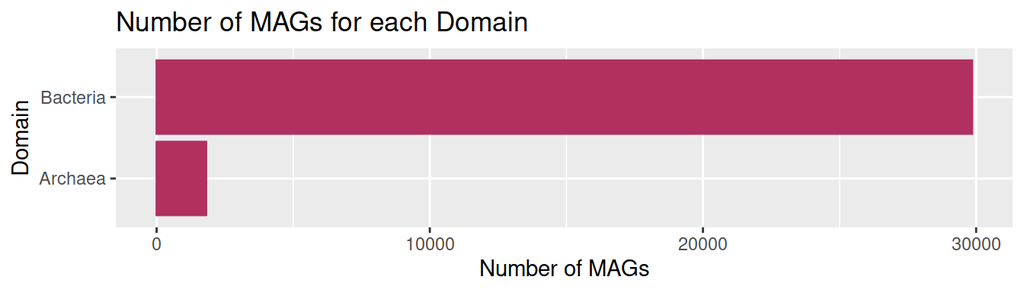

#### Phyla bar chart

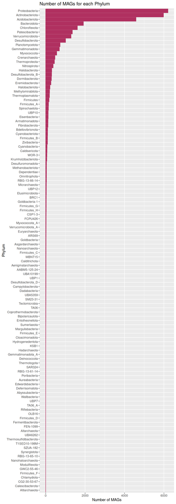

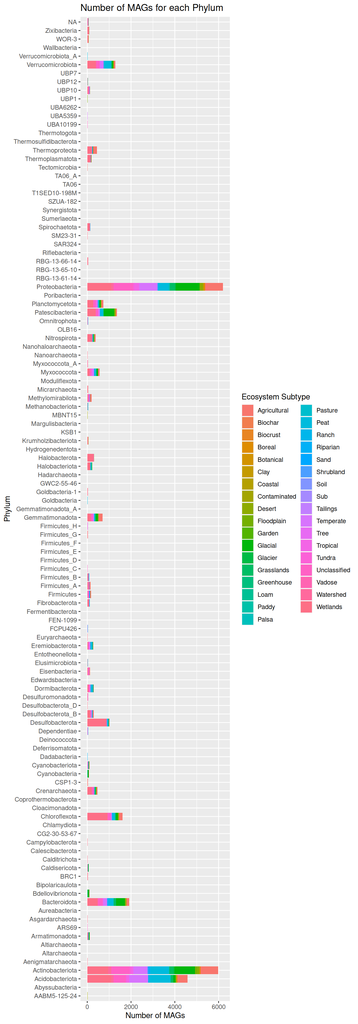

### Pavian Sankey Plot

- [Pavian Github](https://github.com/fbreitwieser/pavian)
- Upload the resulting file to [Pavian Shiny](https://fbreitwieser.shinyapps.io/pavian/)
- Generate html report
- Click on Sample then Configure sankey
- Adjust the graph and the save network
- Caitlin Singleton used a html to svg converter (https://www.hiqpdf.com/demo/ConvertHtmlToSvg.aspx) with aesthetic tweaks in inkscape. * Pavian doesn’t do empty species or genus names (e.g. g__s__). Delete those fields in the file or in inkscape. To show them, create denovo genera and species names so they are unique and cluster appropriately.

```r
IMG_metabat_analysis_GTDB_allTaxa <- bind_rows(IMG_metabat_analysis_GTDB_s, IMG_metabat_analysis_GTDB_g, IMG_metabat_analysis_GTDB_f, IMG_metabat_analysis_GTDB_o, IMG_metabat_analysis_GTDB_c, IMG_metabat_analysis_GTDB_p, IMG_metabat_analysis_GTDB_d) %>%
  mutate(classification = as.factor(classification)) %>%
  count(classification) %>%
# rename for Pavian format
  rename(`#SampleID` = `classification`) %>%
  rename(`Metaphlan2_Analysis` = `n`)
```

```r
write_tsv(IMG_metabat_analysis_GTDB_allTaxa, "IMG_metabat_analysis_GTDB_pavian.txt")
```